# Central Limit Theorem Simulations

Matthew Gast

June 2015

# Overview

This paper uses a simulation to explore the Central Limit Theorem (CLT). By dividing a large collection of exponential random variables into smaller groups and taking the mean of those groups, it is possible to create a normal distribution, even though the underlying random values are exponentially distributed. The simulation in this paper demonstrates that sample means from an exponential distribution are normally distributed.

# Simulations

This analysis will use 1,000 samples of the exponential distribution, each consisting of 40 numbers. To enable readers of the paper to customize the simulation, these size variables are defined as the variables `samples` and `size`, respectively. The exponential distribution also takes one parameter, $\lambda$, which this paper sets to 0.2. Finally, the paper also sets the confidence level for statistical tests, $\alpha$=0.05.

```r
samples <- 1000
size <- 40
lambda <- 0.2
alpha <- .05
```

Begin by generating the raw data, and store it in the matrix `rnds`. Each row within `rnds` is a sample of data, and the data is stored across columns.

```r
for (i in 1:samples) { expRun <- rexp(size, lambda) ; rnds <- rbind(rnds, expRun) }
```

# Means: Sample and Theoretical

The theoretical mean of the exponential distribution is $1/\lambda$; in this case, the theoretical mean is therefore 5. To obtain the sample means of the simulated data, we call the `rowMeans()` function to get a mean value for each sample.

```r
theoMean <- 1/lambda
rnd_means <- rowMeans(rnds)
sampleMean <- mean(rnd_means)
sampleMean
```

```
## [1] 5.055576
```

```r
meanTest <- t.test(rnd_means,mu=theoMean,alternative="two.sided",conf.level=(1-alpha))
meanTest$conf.int
```

```
## [1] 5.005895 5.105258
## attr(,"conf.level")
## [1] 0.95
```

To look at the distribution of means, consider the following histogram. The histogram is drawn to show the distribution of sample means. A red vertical line shows the mean value of the sample means, while the blue vertical line shows the theoretical value. The two are quite close together, as expected. Additionally, the normal distribution is superimposed in green.

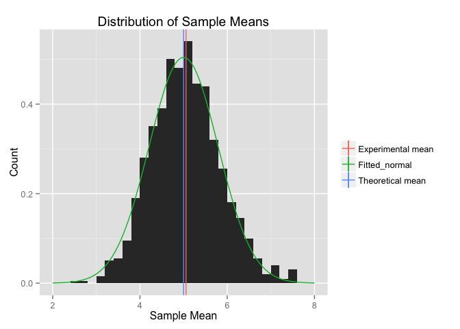

# Variance: Sample versus Theoretical

Next, consider the variance of sample means. The theoretical value for the variance of sample means is given by the distribution variance divided by the size of the sample. In the case of the exponential distribution, the variance is $1/\lambda$<sup>2</sup>, and the sample size is 40, so the variance will be $1/(size * \lambda^2)$, or 0.625.

The variance is distributed according to the the $\chi$<sup>2</sup> distribution, which is asymmetric. To see if the variance lies within the confidence interval, we construct the confidence interval in the same manner as before, but we use the $\chi$<sup>2</sup> distribution. As expected, the theoretical variance is included within the confidence interval of the sample variance.

```r
theoVar <- 1/(size*lambda^2)
sampleVar <- var (rnd_means)
var_low <- sampleVar*(samples-1)/qchisq((1-alpha/2),(samples-1))
var_high <- sampleVar*(samples-1)/qchisq((alpha/2),(samples-1))
c(var_low,var_high)
```

```
## [1] 0.5882784 0.7011198
```

```r
theoVar
```

```
## [1] 0.625
```

# Distribution

The distribution of sample means should be approximately normal. In addition to assessing fit visually versus the curve in the plot above, consider a quantile-quantile (Q-Q) plot. The Q-Q plot shows the theoretical quantile of an observation versus its position in the sample. This paper defines the function `gg_qq` to draw Q-Q plots for various distributions, and additionally overlays a confidence region on the plot.[^1] If plotted data lies within the confidence region, it matches the given distribution.

First, look at a Q-Q plot of the sample means for the normal distribution. The data are broadly consistent with the hypothesis that the data are normally distributed.

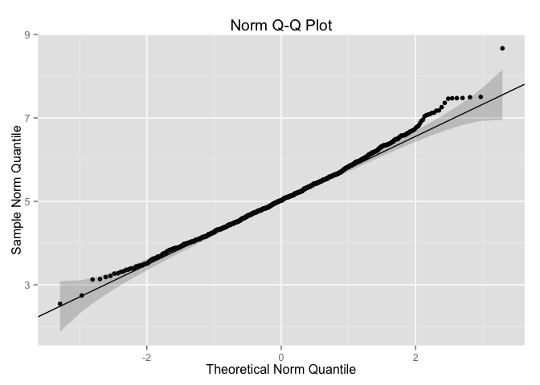

As a contrast to the Q-Q plot showing the normal distribution of the 1000 sample means, consider the entire set of random numbers. If the overall collection is examined in a normal Q-Q plot as in the left panel below, it fails to look remotely like the normal distribution. However, when plotted in an exponential Q-Q plot on the right, it matches the theoretical line quite well. Therefore, we can demonstrate that although the entire pool of simulated data is clearly exponentially distributed because it matches the exponental Q-Q plot, the sample means are normally distributed.

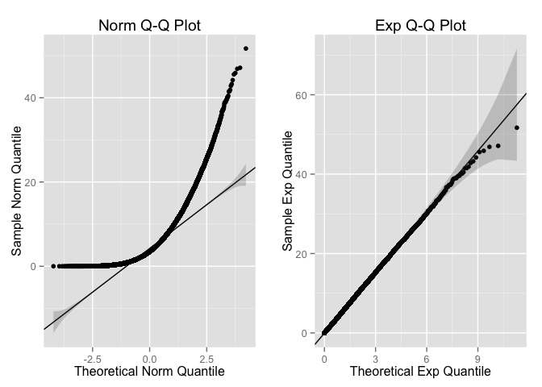

[^1]: The `gg_qq` function was customized from *Foo0*’s post on StackOverflow: http://stackoverflow.com/questions/4357031/qqnorm-and-qqline-in-ggplot2